# 主成分分析

基本的な考え方

村田 昇

# 講義の内容

- **第1日 : 主成分分析の考え方**
- 第2日 : 分析の評価と視覚化

# 主成分分析の考え方

## 主成分分析

- 多数の変量のもつ情報の分析・視覚化
  - 変量を効率的に縮約して少数の特徴量を構成する
  - 特徴量に関与する変量間の関係を明らかにする
- **PCA** (Principal Component Analysis)
  - 構成する特徴量 : **主成分** (princial component)

## 主成分分析の例

都道府県別の人口関連データ

| 都道府県名 | 地方区分 | 昼夜人口比 | 年少人口比 | 老年人口比 | 人口増減率 | 粗出生率 | 粗死亡率 | 婚姻率 | 離婚率 |
| --- | --- | --- | --- | --- | --- | --- | --- | --- | --- |
| 北海道 | 北海道 | 100.0 | 11.7 | 26.0 | -0.47 | 7.09 | 10.63 | 4.86 | 2.12 |
| 青森県 | 東北 | 100.0 | 12.1 | 27.0 | -0.95 | 6.79 | 12.81 | 4.33 | 1.78 |
| 岩手県 | 東北 | 99.7 | 12.4 | 27.9 | -0.84 | 7.12 | 12.33 | 4.32 | 1.52 |
| 宮城県 | 東北 | 100.2 | 13.0 | 22.9 | -0.09 | 8.05 | 9.51 | 5.30 | 1.70 |
| 秋田県 | 東北 | 99.9 | 11.1 | 30.7 | -1.12 | 6.16 | 13.98 | 3.78 | 1.41 |
| 山形県 | 東北 | 99.8 | 12.6 | 28.3 | -0.78 | 7.13 | 12.81 | 4.24 | 1.46 |
| 福島県 | 東北 | 99.6 | 12.9 | 26.1 | -1.41 | 7.02 | 11.94 | 4.73 | 1.64 |
| 茨城県 | 関東 | 97.2 | 13.2 | 23.8 | -0.51 | 7.78 | 10.20 | 4.92 | 1.79 |
| 栃木県 | 関東 | 99.1 | 13.2 | 23.2 | -0.40 | 8.02 | 10.43 | 5.13 | 1.85 |
| 群馬県 | 関東 | 99.9 | 13.4 | 24.9 | -0.45 | 7.49 | 10.63 | 4.64 | 1.77 |
| 埼玉県 | 関東 | 88.6 | 13.0 | 22.0 | 0.07 | 7.90 | 8.20 | 5.10 | 1.86 |
| 千葉県 | 関東 | 89.5 | 12.8 | 23.2 | -0.31 | 7.89 | 8.59 | 5.19 | 1.86 |
| 東京都 | 関東 | 118.4 | 11.3 | 21.3 | 0.26 | 8.12 | 8.25 | 6.75 | 1.91 |
| 神奈川県 | 関東 | 91.2 | 13.0 | 21.5 | 0.10 | 8.32 | 7.94 | 5.68 | 1.85 |
| 新潟県 | 中部 | 100.0 | 12.5 | 27.2 | -0.64 | 7.45 | 11.97 | 4.35 | 1.37 |
| 富山県 | 中部 | 99.8 | 12.7 | 27.6 | -0.55 | 7.28 | 11.79 | 4.50 | 1.43 |
| 石川県 | 中部 | 100.2 | 13.4 | 25.0 | -0.26 | 8.21 | 10.51 | 4.91 | 1.52 |
| 福井県 | 中部 | 100.1 | 13.7 | 26.0 | -0.50 | 8.40 | 11.01 | 4.55 | 1.55 |
| 山梨県 | 中部 | 99.0 | 12.9 | 25.6 | -0.58 | 7.44 | 11.21 | 4.60 | 1.87 |
| 長野県 | 中部 | 99.9 | 13.5 | 27.4 | -0.47 | 7.81 | 11.48 | 4.67 | 1.66 |
| 岐阜県 | 中部 | 96.0 | 13.7 | 25.2 | -0.48 | 8.00 | 10.45 | 4.62 | 1.60 |
| 静岡県 | 中部 | 99.9 | 13.4 | 24.9 | -0.37 | 8.25 | 10.23 | 5.17 | 1.84 |
| 愛知県 | 中部 | 101.5 | 14.2 | 21.4 | 0.15 | 9.14 | 8.26 | 5.75 | 1.82 |
| 三重県 | 関西 | 98.1 | 13.5 | 25.3 | -0.38 | 8.00 | 10.44 | 4.89 | 1.76 |
| 滋賀県 | 関西 | 96.6 | 14.8 | 21.6 | 0.07 | 9.35 | 8.64 | 5.22 | 1.66 |
| 京都府 | 関西 | 101.2 | 12.6 | 24.7 | -0.27 | 7.66 | 9.68 | 5.02 | 1.77 |
| 大阪府 | 関西 | 104.7 | 13.0 | 23.7 | -0.06 | 8.24 | 9.09 | 5.43 | 2.12 |
| 兵庫県 | 関西 | 95.7 | 13.5 | 24.3 | -0.20 | 8.34 | 9.63 | 5.07 | 1.84 |
| 奈良県 | 関西 | 89.9 | 12.9 | 25.5 | -0.43 | 7.60 | 9.82 | 4.48 | 1.72 |
| 和歌山県 | 関西 | 98.1 | 12.5 | 28.4 | -0.70 | 7.51 | 12.59 | 4.72 | 1.98 |
| 鳥取県 | 中国 | 100.0 | 13.2 | 27.2 | -0.51 | 8.20 | 12.15 | 4.74 | 1.83 |
| 島根県 | 中国 | 100.0 | 12.7 | 30.0 | -0.70 | 7.90 | 13.46 | 4.40 | 1.43 |
| 岡山県 | 中国 | 99.9 | 13.5 | 26.2 | -0.26 | 8.41 | 10.94 | 4.94 | 1.82 |
| 広島県 | 中国 | 100.3 | 13.5 | 25.3 | -0.25 | 8.72 | 10.28 | 5.15 | 1.78 |
| 山口県 | 中国 | 99.5 | 12.6 | 29.2 | -0.76 | 7.55 | 12.74 | 4.58 | 1.67 |
| 徳島県 | 四国 | 99.7 | 12.2 | 28.0 | -0.51 | 7.40 | 12.60 | 4.34 | 1.62 |
| 香川県 | 四国 | 100.2 | 13.2 | 27.1 | -0.30 | 8.25 | 11.50 | 4.84 | 1.91 |
| 愛媛県 | 四国 | 100.1 | 12.8 | 27.8 | -0.56 | 7.87 | 12.17 | 4.51 | 1.79 |
| 高知県 | 四国 | 99.9 | 11.9 | 30.1 | -0.79 | 7.00 | 13.49 | 4.33 | 1.87 |
| 福岡県 | 九州 | 100.1 | 13.5 | 23.3 | 0.12 | 9.01 | 9.63 | 5.50 | 2.07 |
| 佐賀県 | 九州 | 100.2 | 14.4 | 25.3 | -0.47 | 8.83 | 11.48 | 4.75 | 1.74 |
| 長崎県 | 九州 | 99.8 | 13.4 | 27.0 | -0.64 | 8.33 | 11.92 | 4.50 | 1.74 |
| 熊本県 | 九州 | 99.6 | 13.7 | 26.5 | -0.33 | 8.85 | 11.38 | 4.96 | 1.87 |
| 大分県 | 九州 | 100.0 | 12.9 | 27.6 | -0.50 | 8.14 | 11.86 | 4.77 | 1.85 |
| 宮崎県 | 九州 | 100.0 | 13.8 | 26.7 | -0.44 | 8.75 | 11.59 | 5.03 | 2.15 |
| 鹿児島県 | 九州 | 99.9 | 13.6 | 27.0 | -0.53 | 8.78 | 12.59 | 4.78 | 1.84 |
| 沖縄県 | 九州 | 100.0 | 17.6 | 17.7 | 0.57 | 12.12 | 7.54 | 6.28 | 2.58 |

### 人口関連データの散布図

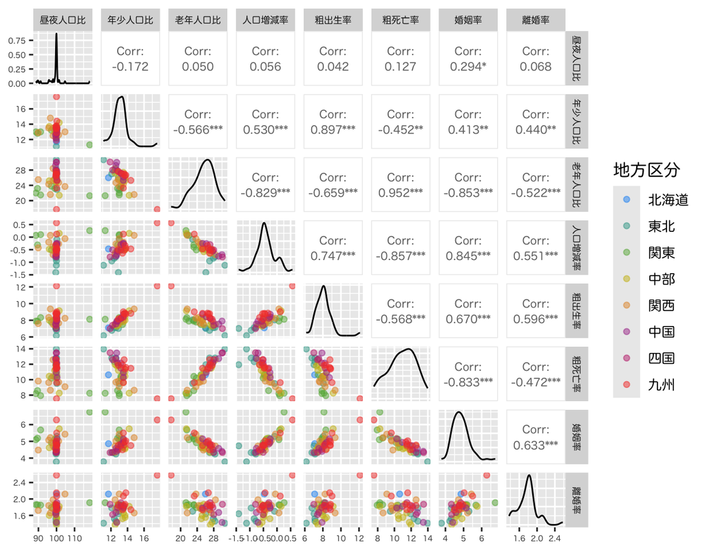

### 主成分得点のバイプロット

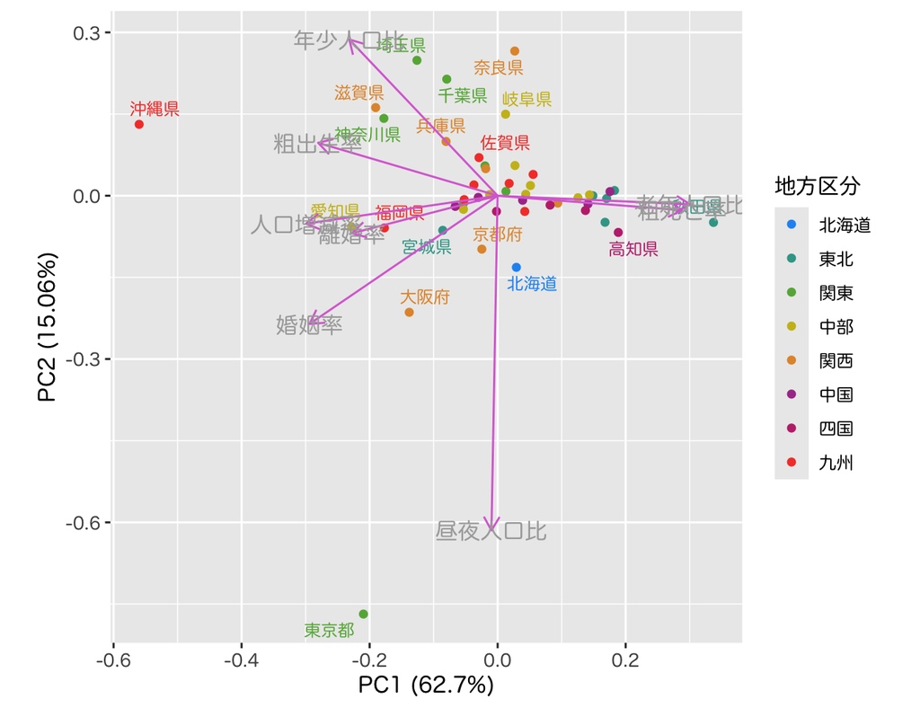

## 分析の枠組み

- $x_{1},\dotsc,x_{p}$ : **変数**
- $z_{1},\dotsc,z_{d}$ : **特徴量** ( $d\leq p$ )
- 変数と特徴量の関係 (線形結合)
  $$\begin{equation}
  z_k=a_{1k}x_{1}+\cdots+a_{pk}x_{p}\quad(k=1,\dotsc,d)
  \end{equation}$$
  - 特徴量は定数倍の任意性があるので以下を仮定
    $$\begin{equation}
    \|\boldsymbol{a}_k\|^2=\sum_{j=1}^pa_{jk}^2=1
    \end{equation}$$

## 主成分分析の用語

- 特徴量 $z_k$
  - 第 $k$ **主成分得点** (principal component score)
  - 第 $k$ **主成分**
- 係数ベクトル $\boldsymbol{a}_k$
  - 第 $k$ **主成分負荷量** (principal component loading)
  - 第 $k$ **主成分方向** (principal component direction)

## 分析の目的

- 目的  
  主成分得点 $z_{1},\dots,z_{d}$ が変数 $x_{1},\dotsc,x_{p}$ の情報を効率よく反映するように主成分負荷量 $\boldsymbol{a}_{1},\dotsc,\boldsymbol{a}_{d}$ を観測データから決定する
- 分析の方針 (以下は同値)
  - データの情報を最も保持する変量の **線形結合を構成**
  - データの情報を最も反映する **座標軸を探索**
- **教師なし学習** の代表的手法の1つ
  - 特徴抽出 : 情報処理に重要な特性を変数に凝集
  - 次元縮約 : 入力をできるだけ少ない変数で表現

# 第1主成分の計算

## 記号の準備

- 変数 : $x_{1},\dotsc,x_{p}$ ($p$次元)
- 観測データ : $n$ 個の $(x_{1},\dotsc,x_{p})$ の組
  $$\begin{equation}
  \{(x_{i1},\dots,x_{ip})\}_{i=1}^n
  \end{equation}$$
- ベクトル表現
  - $\boldsymbol{x}_{i}=(x_{i1},\dots,x_{ip})^{\mathsf{T}}$ : $i$ 番目の観測データ ($p$ 次元空間内の1点)
  - $\boldsymbol{a}=(a_{1},\dots,a_{p})^{\mathsf{T}}$ : 長さ1の $p$ 次元ベクトル

## 係数ベクトルによる射影

- データ $\boldsymbol{x}_{i}$ の $\boldsymbol{a}$ 方向成分の長さ
  $$\begin{equation}
  \boldsymbol{a}^{\mathsf{T}}\boldsymbol{x}_{i}
  \quad\text{(スカラー)}
  \end{equation}$$
- 方向ベクトル $\boldsymbol{a}$ をもつ直線上への点 $\boldsymbol{x}_{i}$ の直交射影
  $$\begin{equation}
  (\boldsymbol{a}^{\mathsf{T}}\boldsymbol{x}_{i})\,\boldsymbol{a}
  \quad\text{(スカラー \(\times\) ベクトル)}
  \end{equation}$$

## 幾何学的描像

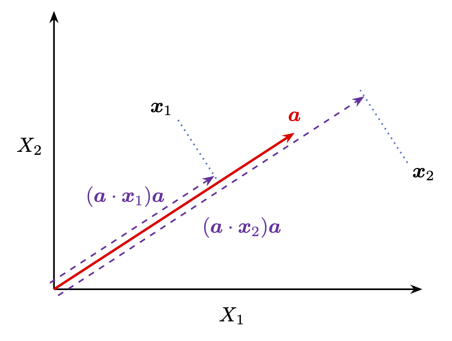

観測データの直交射影 ($p=2,n=2$ の場合)

## ベクトル $\boldsymbol{a}$ の選択の指針

- 射影による特徴量の構成
  ベクトル $\boldsymbol{a}$ を **うまく** 選んで 観測データ $\boldsymbol{x}_{1},\cdots,\boldsymbol{x}_{n}$ の情報を最も保持する1変量データ $z_{1},\cdots,z_{n}$を構成
  $$\begin{equation}
  z_{1}=\boldsymbol{a}^{\mathsf{T}}\boldsymbol{x}_{1},
  z_{2}=\boldsymbol{a}^{\mathsf{T}}\boldsymbol{x}_2,
  \dotsc,
  z_{n}=\boldsymbol{a}^{\mathsf{T}}\boldsymbol{x}_n
  \end{equation}$$
- 特徴量のばらつきの最大化
  観測データの **ばらつき** を最も反映するベクトル $\boldsymbol{a}$ を選択
  $$\begin{equation}
  \arg\max_{\boldsymbol{a}}
  \sum_{i=1}^n(\boldsymbol{a}^{\mathsf{T}}\boldsymbol{x}_{i}
  -\boldsymbol{a}^{\mathsf{T}}\bar{\boldsymbol{x}})^2,
  \quad
  \bar{\boldsymbol{x}}
  =
  \frac{1}{n}\sum_{i=1}^n\boldsymbol{x}_{i},
  \end{equation}$$

## ベクトル $\boldsymbol{a}$ の最適化

- 最適化問題
  制約条件 $\|\boldsymbol{a}\|=1$ の下で 以下の関数を最大化せよ
  $$\begin{equation}
  f(\boldsymbol{a})
  =
  \sum_{i=1}^n(\boldsymbol{a}^{\mathsf{T}}\boldsymbol{x}_{i}
  -\boldsymbol{a}^{\mathsf{T}}\bar{\boldsymbol{x}})^2
  \end{equation}$$
- この最大化問題は必ず解をもつ
  - $f(\boldsymbol{a})$ は連続関数
  - 集合 $\{\boldsymbol{a}\in\mathbb{R}^p:\|\boldsymbol{a}\|=1\}$ はコンパクト(有界閉集合)

# 演習

## 問題

- 以下の問に答えなさい
  - 評価関数 $f(\boldsymbol{a})$ を以下の中心化したデータ行列で表しなさい
    $$\begin{equation}
    X
    =
    \begin{pmatrix}
    \boldsymbol{x}_{1}^{\mathsf{T}}-\bar{\boldsymbol{x}}^{\mathsf{T}} \\
    \vdots \\
    \boldsymbol{x}_{n}^{\mathsf{T}}-\bar{\boldsymbol{x}}^{\mathsf{T}}
    \end{pmatrix}
    =
    \begin{pmatrix}
    x_{11}-\bar{x}_{1} & \cdots & x_{1p}-\bar{x}_{p}\\
    \vdots & & \vdots \\
    x_{n1}-\bar{x}_{1} & \cdots & x_{np}-\bar{x}_{p}
    \end{pmatrix}
    \end{equation}$$
  - 上の結果を用いて次の最適化問題の解の条件を求めなさい
    $$\begin{equation}
    \text{maximize}\quad
    f(\boldsymbol{a})
    \quad\text{s.t.}\quad
    \boldsymbol{a}^{\mathsf{T}}\boldsymbol{a}=1
    \end{equation}$$

# 第1主成分の解

## ベクトル $\boldsymbol{a}$ の解

- 最適化問題
  $$\begin{equation}
  \text{maximize}\quad
  f(\boldsymbol{a})
  =
  \boldsymbol{a}^{\mathsf{T}}X^{\mathsf{T}}X\boldsymbol{a}
  \quad\text{s.t.}\quad
  \boldsymbol{a}^{\mathsf{T}}\boldsymbol{a}=1
  \end{equation}$$
- 固有値問題
  $f(\boldsymbol{a})$ の極大値を与える $\boldsymbol{a}$ は $X^{\mathsf{T}}X$ の固有ベクトルとなる
  $$\begin{equation}
  X^{\mathsf{T}}X\boldsymbol{a}
  =
  \lambda\boldsymbol{a}
  \end{equation}$$

## 第1主成分

- 固有ベクトル$\boldsymbol{a}$に対する$f(\boldsymbol{a})$ は行列 $X^{\mathsf{T}}X$ の固有値
  $$\begin{equation}
  f(\boldsymbol{a})
  =\boldsymbol{a}^{\mathsf{T}}X^{\mathsf{T}}X\boldsymbol{a}
  =\boldsymbol{a}^{\mathsf{T}}\lambda\boldsymbol{a}
  =\lambda
  \end{equation}$$
- 求める $\boldsymbol{a}$ は行列 $X^{\mathsf{T}}X$ の最大固有ベクトル (長さ1)
- **第1主成分負荷量** : 最大(第一)固有ベクトル $\boldsymbol{a}$
- **第1主成分得点**
  $$\begin{equation}
  z_{i1}
  =a_{1}x_{i1}+\cdots+a_{p}x_{ip}
  =\boldsymbol{a}^{\mathsf{T}}\boldsymbol{x}_{i},
  \quad(i=1,\dots,n)
  \end{equation}$$

# Gram 行列の性質

## Gram 行列の固有値

- $X^{\mathsf{T}}X$ は半正定値行列
- $X^{\mathsf{T}}X$ の固有値は0以上の実数
  - 固有値を重複を許して降順に並べる
    $$\begin{equation}
    \lambda_{1}\geq\dotsb\geq\lambda_{p}\quad(\geq0)
    \end{equation}$$
  - 固有値 $\lambda_{k}$ に対する固有ベクトルを $\boldsymbol{a}_{k}$(長さ1)とする
    $$\begin{equation}
    \|\boldsymbol{a}_{k}\|=1,
    \quad (k=1,\dotsc,p)
    \end{equation}$$

## Gram 行列のスペクトル分解

- $\boldsymbol{a}_{1},\dotsc,\boldsymbol{a}_{p}$ は **互いに直交** するようとることができる
  $$\begin{equation}
  j\neq k
  \quad\Rightarrow\quad
  \boldsymbol{a}_{j}^{\mathsf{T}}\boldsymbol{a}_k=0
  \end{equation}$$
- 行列 $X^{\mathsf{T}}X$ (半正定値行列) のスペクトル分解
  $$\begin{align}
  X^{\mathsf{T}}X
  &=\lambda_{1}\boldsymbol{a}_{1}\boldsymbol{a}_{1}^{\mathsf{T}}+
  \lambda_{2}\boldsymbol{a}_{2}\boldsymbol{a}_{2}^{\mathsf{T}}+
  \dotsb+\lambda_{p}\boldsymbol{a}_{p}\boldsymbol{a}_{p}^{\mathsf{T}}\\
  &=\sum_{k=1}^{p}\lambda_{k}\boldsymbol{a}_{k}\boldsymbol{a}_{k}^{\mathsf{T}}
  \end{align}$$
  - 固有値と固有ベクトルによる行列の表現

# 演習

## 問題

- 以下の問に答えなさい
  - Gram 行列のスペクトル分解において $\lambda_{j}$ と $\boldsymbol{a}_{j}$ が固有値・固有ベクトルとなることを確かめなさい
    $$\begin{equation}
    X^{\mathsf{T}}X
    =\sum_{k=1}^{p}\lambda_{k}\boldsymbol{a}_{k}\boldsymbol{a}_{k}^{\mathsf{T}}
    \end{equation}$$
  - 以下の行列を用いて Gram 行列のスペクトル分解を書き直しなさい
    $$\begin{equation}
    A
    =
    \begin{pmatrix}
    \boldsymbol{a}_{1}^{\mathsf{T}}\\
    \vdots \\
    \boldsymbol{a}_{p}^{\mathsf{T}}
    \end{pmatrix},
    \quad
    \Lambda
    =
    \begin{pmatrix}
    \lambda_{1} & 0 & \dotsm & 0\\
    0 & \lambda_{2} & \dotsm & 0\\
    0 & 0 & \ddots & 0\\
    0 & 0 & \dotsm & \lambda_{p}\\
    \end{pmatrix}
    \end{equation}$$

# 第2主成分以降の計算

## 第2主成分の考え方

- 第1主成分
  - 主成分負荷量 : ベクトル $\boldsymbol{a}_{1}$
  - 主成分得点 : $\boldsymbol{a}_{1}^{\mathsf{T}}\boldsymbol{x}_{i}$ ($i=1,\dotsc,n$)
- 第1主成分負荷量に関してデータが有する情報
  $$\begin{equation}
  (\boldsymbol{a}_{1}^{\mathsf{T}}\boldsymbol{x}_{i})\,\boldsymbol{a}_{1}
  \quad(i=1,\dotsc,n)
  \end{equation}$$
- 第1主成分を取り除いた観測データ (分析対象)
  $$\begin{equation}
  \tilde{\boldsymbol{x}}_{i}
  =
  \boldsymbol{x}_{i}
  -(\boldsymbol{a}_{1}^{\mathsf{T}}\boldsymbol{x}_{i})\,\boldsymbol{a}_{1}
  \quad(i=1,\dotsc,n)
  \end{equation}$$

## 第2主成分の最適化

- 最適化問題
  制約条件 $\|\boldsymbol{a}\|=1$ の下で 以下の関数を最大化せよ
  $$\begin{equation}
  \tilde{f}(\boldsymbol{a})
  =
  \sum_{i=1}^n(\boldsymbol{a}^{\mathsf{T}}\tilde{\boldsymbol{x}}_{i}
  -\boldsymbol{a}^{\mathsf{T}}\bar{\tilde{\boldsymbol{x}}})^2
  \quad\text{ただし}\quad
  \bar{\tilde{\boldsymbol{x}}}
  =
  \frac{1}{n}\sum_{i=1}^n\tilde{\boldsymbol{x}}_{i}
  \end{equation}$$

# 演習

## 問題

- 以下の問に答えなさい
  - 以下の中心化したデータ行列を $X$ と $\boldsymbol{a}_{1}$ で表しなさい
    $$\begin{equation}
    \tilde{X}
    =
    \begin{pmatrix}
    \tilde{\boldsymbol{x}}_{1}^{\mathsf{T}}-\bar{\tilde{\boldsymbol{x}}}^{\mathsf{T}} \\
    \vdots \\
    \tilde{\boldsymbol{x}}_{n}^{\mathsf{T}}-\bar{\tilde{\boldsymbol{x}}}^{\mathsf{T}}
    \end{pmatrix}
    \end{equation}$$
  - 上の結果を用いて 次の最適化問題の解を求めなさい
    $$\begin{equation}
    \text{maximize}\quad
    \tilde{f}(\boldsymbol{a})
    \quad\text{s.t.}\quad
    \boldsymbol{a}^{\mathsf{T}}\boldsymbol{a}=1
    \end{equation}$$

# 第2主成分以降の解

## 第2主成分

- Gram 行列 $\tilde{X}^{\mathsf{T}}\tilde{X}$ の固有ベクトル $\boldsymbol{a}_{1}$ の固有値は 0
  $$\begin{equation}
  \tilde{X}^{\mathsf{T}}\tilde{X}\boldsymbol{a}_{1}
  = 0
  \end{equation}$$
- Gram 行列 $\tilde{X}^{\mathsf{T}}\tilde{X}$ の最大固有値は $\lambda_2$
- 解は第2固有値 $\lambda_2$ に対応する固有ベクトル $\boldsymbol{a}_2$
- 以下同様に 第 $k$ 主成分負荷量は $X^{\mathsf{T}}X$ の第 $k$ 固有値 $\lambda_k$ に対応する固有ベクトル $\boldsymbol{a}_k$

# 解析の事例

## データセットについて

- 総務省統計局より取得した都道府県別の社会生活統計指標(自然環境・経済基盤)の一部
  - 総務省 https://www.e-stat.go.jp/SG1/estat/List.do?bid=000001083999&cycode=0
  - 整理したものを `japan_social.csv` として配布
    - 都道府県名
    - 地方区分
    - 森林面積割合 (%) 2014年
    - 就業者１人当たり農業産出額(販売農家）(万円) 2014年
    - 全国総人口に占める人口割合 (%) 2015年
    - 土地生産性（耕地面積１ヘクタール当たり）(万円) 2014年
    - 商業年間商品販売額［卸売業＋小売業］（事業所当たり）(百万円) 2013年

## 社会生活統計指標の分析

都道府県別の自然環境・経済基盤データ

| 都道府県名 | 地方区分 | 森林面積割合 | 農業産出額 | 人口割合 | 土地生産性 | 商品販売額 |
| --- | --- | --- | --- | --- | --- | --- |
| 北海道 | 北海道 | 67.9 | 1150.6 | 4.23 | 96.8 | 283.3 |
| 青森県 | 東北 | 63.8 | 444.7 | 1.03 | 186.0 | 183.0 |
| 岩手県 | 東北 | 74.9 | 334.3 | 1.01 | 155.2 | 179.4 |
| 宮城県 | 東北 | 55.9 | 299.9 | 1.84 | 125.3 | 365.9 |
| 秋田県 | 東北 | 70.5 | 268.7 | 0.81 | 98.5 | 153.3 |
| 山形県 | 東北 | 68.7 | 396.3 | 0.88 | 174.1 | 157.5 |
| 福島県 | 東北 | 67.9 | 236.4 | 1.51 | 127.1 | 184.5 |
| 茨城県 | 関東 | 31.0 | 479.0 | 2.30 | 249.1 | 204.9 |
| 栃木県 | 関東 | 53.2 | 402.6 | 1.55 | 199.6 | 204.3 |
| 群馬県 | 関東 | 63.8 | 530.6 | 1.55 | 321.6 | 270.0 |
| 埼玉県 | 関東 | 31.9 | 324.7 | 5.72 | 247.0 | 244.7 |
| 千葉県 | 関東 | 30.4 | 565.5 | 4.90 | 326.1 | 219.7 |
| 東京都 | 関東 | 34.8 | 268.5 | 10.63 | 404.7 | 1062.6 |
| 神奈川県 | 関東 | 38.8 | 322.8 | 7.18 | 396.4 | 246.1 |
| 新潟県 | 中部 | 63.5 | 308.6 | 1.81 | 141.9 | 205.5 |
| 富山県 | 中部 | 56.6 | 276.1 | 0.84 | 98.5 | 192.4 |
| 石川県 | 中部 | 66.0 | 271.3 | 0.91 | 112.0 | 222.9 |
| 福井県 | 中部 | 73.9 | 216.1 | 0.62 | 98.5 | 167.3 |
| 山梨県 | 中部 | 77.8 | 287.4 | 0.66 | 325.3 | 156.2 |
| 長野県 | 中部 | 75.5 | 280.0 | 1.65 | 211.3 | 194.4 |
| 岐阜県 | 中部 | 79.0 | 283.7 | 1.60 | 192.1 | 167.9 |
| 静岡県 | 中部 | 63.1 | 375.8 | 2.91 | 314.5 | 211.4 |
| 愛知県 | 中部 | 42.2 | 472.3 | 5.89 | 388.9 | 446.9 |
| 三重県 | 関西 | 64.3 | 310.6 | 1.43 | 174.3 | 170.1 |
| 滋賀県 | 関西 | 50.5 | 222.8 | 1.11 | 104.9 | 170.7 |
| 京都府 | 関西 | 74.2 | 267.8 | 2.05 | 212.5 | 196.7 |
| 大阪府 | 関西 | 30.1 | 216.3 | 6.96 | 238.8 | 451.2 |
| 兵庫県 | 関西 | 66.7 | 261.2 | 4.35 | 197.7 | 212.5 |
| 奈良県 | 関西 | 76.8 | 207.0 | 1.07 | 182.7 | 147.0 |
| 和歌山県 | 関西 | 76.4 | 251.1 | 0.76 | 278.4 | 136.4 |
| 鳥取県 | 中国 | 73.3 | 249.9 | 0.45 | 187.6 | 162.2 |
| 島根県 | 中国 | 77.5 | 214.1 | 0.55 | 140.8 | 141.1 |
| 岡山県 | 中国 | 68.0 | 254.8 | 1.51 | 184.9 | 207.8 |
| 広島県 | 中国 | 71.8 | 286.2 | 2.24 | 192.2 | 304.6 |
| 山口県 | 中国 | 71.6 | 216.9 | 1.11 | 125.8 | 158.9 |
| 徳島県 | 四国 | 75.2 | 315.4 | 0.59 | 313.5 | 134.5 |
| 香川県 | 四国 | 46.4 | 249.5 | 0.77 | 242.9 | 232.9 |
| 愛媛県 | 四国 | 70.3 | 288.5 | 1.09 | 231.6 | 179.4 |
| 高知県 | 四国 | 83.3 | 354.2 | 0.57 | 339.9 | 137.9 |
| 福岡県 | 九州 | 44.5 | 381.0 | 4.01 | 255.6 | 295.7 |
| 佐賀県 | 九州 | 45.2 | 468.7 | 0.66 | 230.3 | 137.9 |
| 長崎県 | 九州 | 58.4 | 428.9 | 1.08 | 296.0 | 154.0 |
| 熊本県 | 九州 | 60.4 | 456.6 | 1.41 | 285.5 | 172.5 |
| 大分県 | 九州 | 70.7 | 360.1 | 0.92 | 222.8 | 148.3 |
| 宮崎県 | 九州 | 75.8 | 739.1 | 0.87 | 487.7 | 170.6 |
| 鹿児島県 | 九州 | 63.4 | 736.5 | 1.30 | 351.2 | 169.4 |
| 沖縄県 | 九州 | 46.1 | 452.4 | 1.13 | 232.8 | 145.4 |

### 変数間の関係を見る

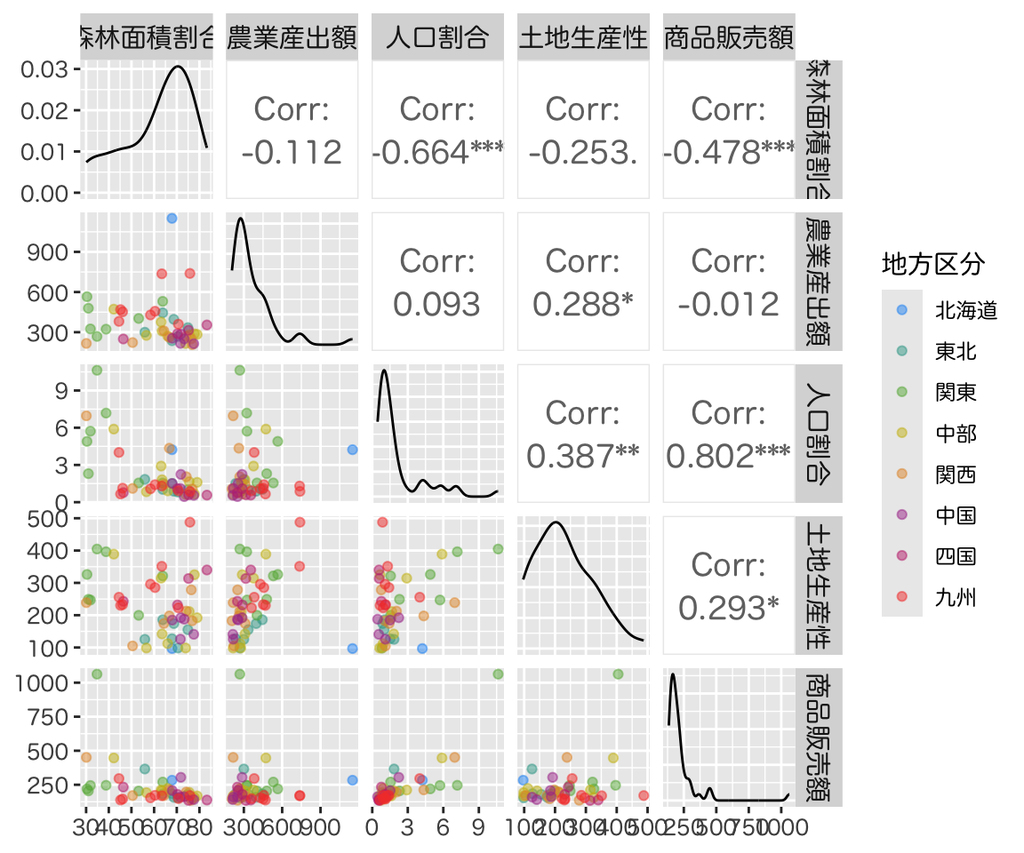

### 変数のばらつきに大きな違いがある

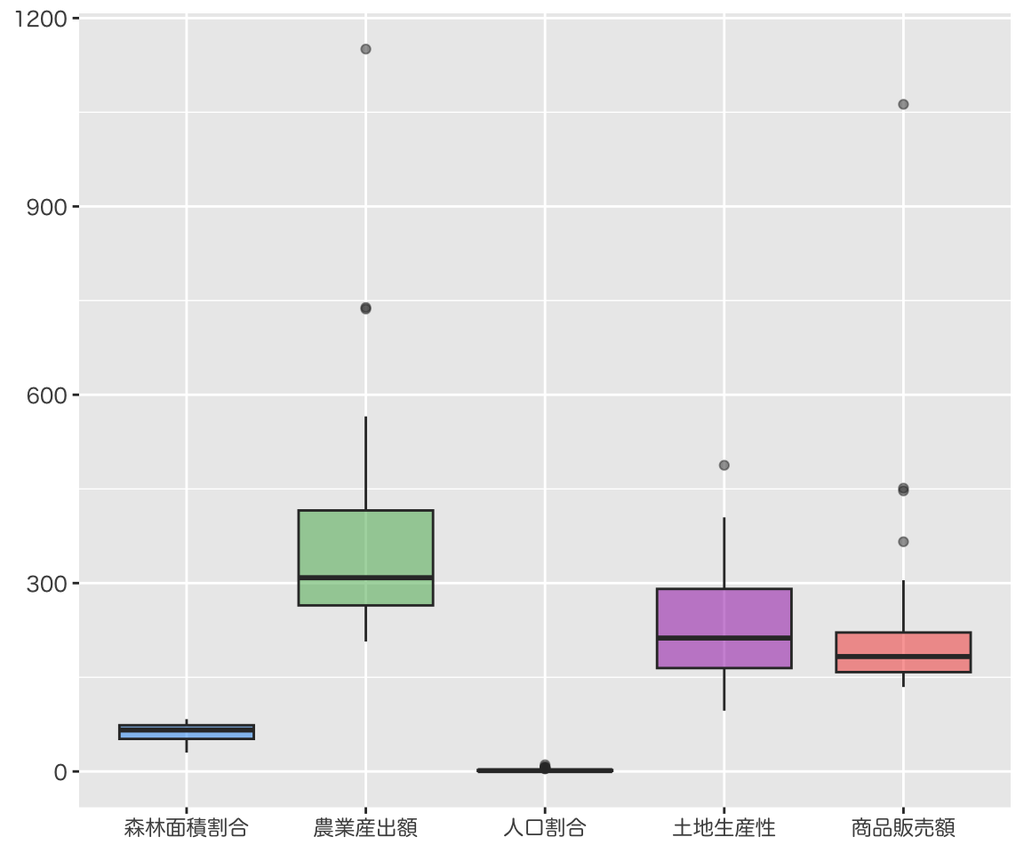

### より詳細な分布を確認する

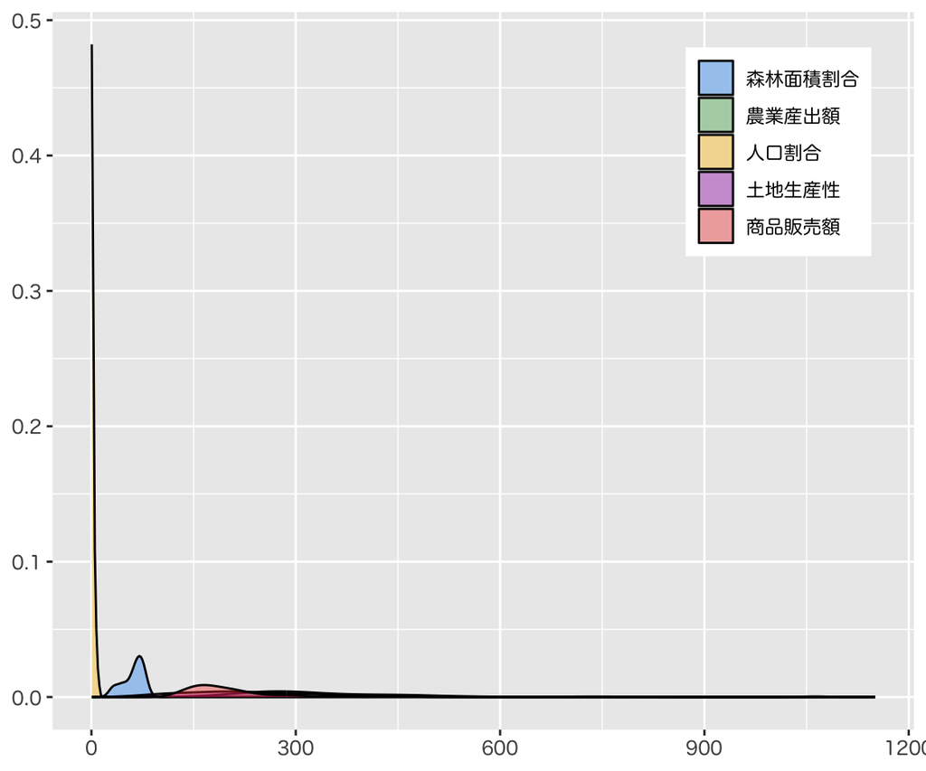

### データのばらつきを揃える

標準化したデータ

| 都道府県名 | 地方区分 | 森林面積割合 | 農業産出額 | 人口割合 | 土地生産性 | 商品販売額 |
| --- | --- | --- | --- | --- | --- | --- |
| 北海道 | 北海道 | 0.4250 | 4.6300 | 0.9790 | -1.4000 | 0.42100 |
| 青森県 | 東北 | 0.1510 | 0.4890 | -0.5120 | -0.4460 | -0.27400 |
| 岩手県 | 東北 | 0.8920 | -0.1590 | -0.5210 | -0.7760 | -0.29900 |
| 宮城県 | 東北 | -0.3760 | -0.3610 | -0.1340 | -1.1000 | 0.99300 |
| 秋田県 | 東北 | 0.5990 | -0.5440 | -0.6140 | -1.3800 | -0.48000 |
| 山形県 | 東北 | 0.4790 | 0.2050 | -0.5810 | -0.5740 | -0.45100 |
| 福島県 | 東北 | 0.4250 | -0.7340 | -0.2880 | -1.0800 | -0.26400 |
| 茨城県 | 関東 | -2.0400 | 0.6910 | 0.0801 | 0.2290 | -0.12300 |
| 栃木県 | 関東 | -0.5560 | 0.2420 | -0.2690 | -0.3010 | -0.12700 |
| 群馬県 | 関東 | 0.1510 | 0.9940 | -0.2690 | 1.0100 | 0.32900 |
| 埼玉県 | 関東 | -1.9800 | -0.2150 | 1.6700 | 0.2070 | 0.15300 |
| 千葉県 | 関東 | -2.0800 | 1.2000 | 1.2900 | 1.0500 | -0.02000 |
| 東京都 | 関東 | -1.7800 | -0.5460 | 3.9600 | 1.9000 | 5.82000 |
| 神奈川県 | 関東 | -1.5200 | -0.2270 | 2.3500 | 1.8100 | 0.16300 |
| 新潟県 | 中部 | 0.1310 | -0.3100 | -0.1480 | -0.9180 | -0.11800 |
| 富山県 | 中部 | -0.3290 | -0.5010 | -0.6000 | -1.3800 | -0.20900 |
| 石川県 | 中部 | 0.2980 | -0.5290 | -0.5670 | -1.2400 | 0.00214 |
| 福井県 | 中部 | 0.8260 | -0.8530 | -0.7030 | -1.3800 | -0.38300 |
| 山梨県 | 中部 | 1.0900 | -0.4350 | -0.6840 | 1.0500 | -0.46000 |
| 長野県 | 中部 | 0.9330 | -0.4780 | -0.2230 | -0.1750 | -0.19500 |
| 岐阜県 | 中部 | 1.1700 | -0.4560 | -0.2460 | -0.3810 | -0.37900 |
| 静岡県 | 中部 | 0.1050 | 0.0846 | 0.3640 | 0.9300 | -0.07760 |
| 愛知県 | 中部 | -1.2900 | 0.6510 | 1.7500 | 1.7300 | 1.56000 |
| 三重県 | 関西 | 0.1850 | -0.2980 | -0.3250 | -0.5720 | -0.36400 |
| 滋賀県 | 関西 | -0.7370 | -0.8140 | -0.4740 | -1.3100 | -0.36000 |
| 京都府 | 関西 | 0.8460 | -0.5500 | -0.0364 | -0.1630 | -0.17900 |
| 大阪府 | 関西 | -2.1000 | -0.8520 | 2.2500 | 0.1190 | 1.58000 |
| 兵庫県 | 関西 | 0.3450 | -0.5880 | 1.0400 | -0.3210 | -0.07000 |
| 奈良県 | 関西 | 1.0200 | -0.9070 | -0.4930 | -0.4820 | -0.52400 |
| 和歌山県 | 関西 | 0.9930 | -0.6480 | -0.6370 | 0.5430 | -0.59800 |
| 鳥取県 | 中国 | 0.7860 | -0.6550 | -0.7820 | -0.4290 | -0.41900 |
| 島根県 | 中国 | 1.0700 | -0.8650 | -0.7350 | -0.9300 | -0.56500 |
| 岡山県 | 中国 | 0.4320 | -0.6260 | -0.2880 | -0.4580 | -0.10300 |
| 広島県 | 中国 | 0.6860 | -0.4420 | 0.0521 | -0.3800 | 0.56900 |
| 山口県 | 中国 | 0.6720 | -0.8490 | -0.4740 | -1.0900 | -0.44200 |
| 徳島県 | 四国 | 0.9130 | -0.2700 | -0.7170 | 0.9190 | -0.61100 |
| 香川県 | 四国 | -1.0100 | -0.6570 | -0.6330 | 0.1630 | 0.07150 |
| 愛媛県 | 四国 | 0.5850 | -0.4280 | -0.4840 | 0.0420 | -0.29900 |
| 高知県 | 四国 | 1.4500 | -0.0422 | -0.7260 | 1.2000 | -0.58700 |
| 福岡県 | 九州 | -1.1400 | 0.1150 | 0.8770 | 0.2990 | 0.50700 |
| 佐賀県 | 九州 | -1.0900 | 0.6300 | -0.6840 | 0.0281 | -0.58700 |
| 長崎県 | 九州 | -0.2090 | 0.3960 | -0.4880 | 0.7320 | -0.47600 |
| 熊本県 | 九州 | -0.0756 | 0.5590 | -0.3350 | 0.6190 | -0.34700 |
| 大分県 | 九州 | 0.6120 | -0.0076 | -0.5630 | -0.0522 | -0.51500 |
| 宮崎県 | 九州 | 0.9530 | 2.2200 | -0.5860 | 2.7800 | -0.36000 |
| 鹿児島県 | 九州 | 0.1250 | 2.2000 | -0.3860 | 1.3200 | -0.36900 |
| 沖縄県 | 九州 | -1.0300 | 0.5340 | -0.4650 | 0.0548 | -0.53500 |

### 変数のばらつきを確認する

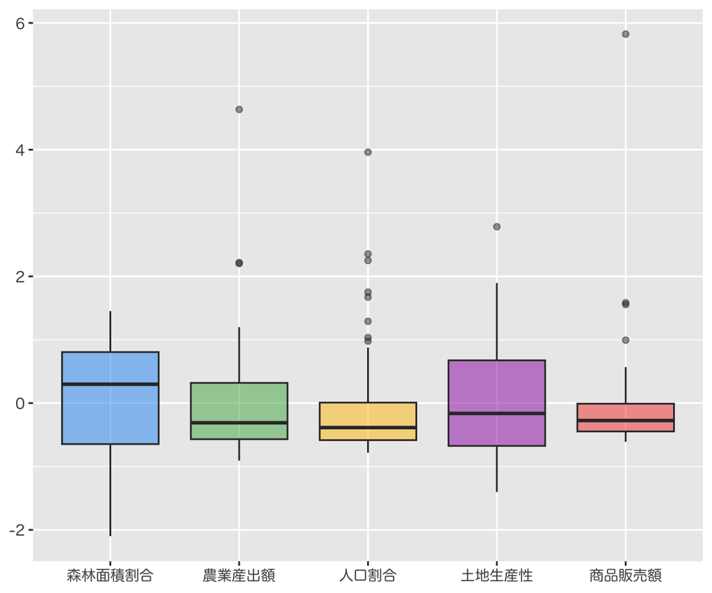

### より詳細な分布を確認する

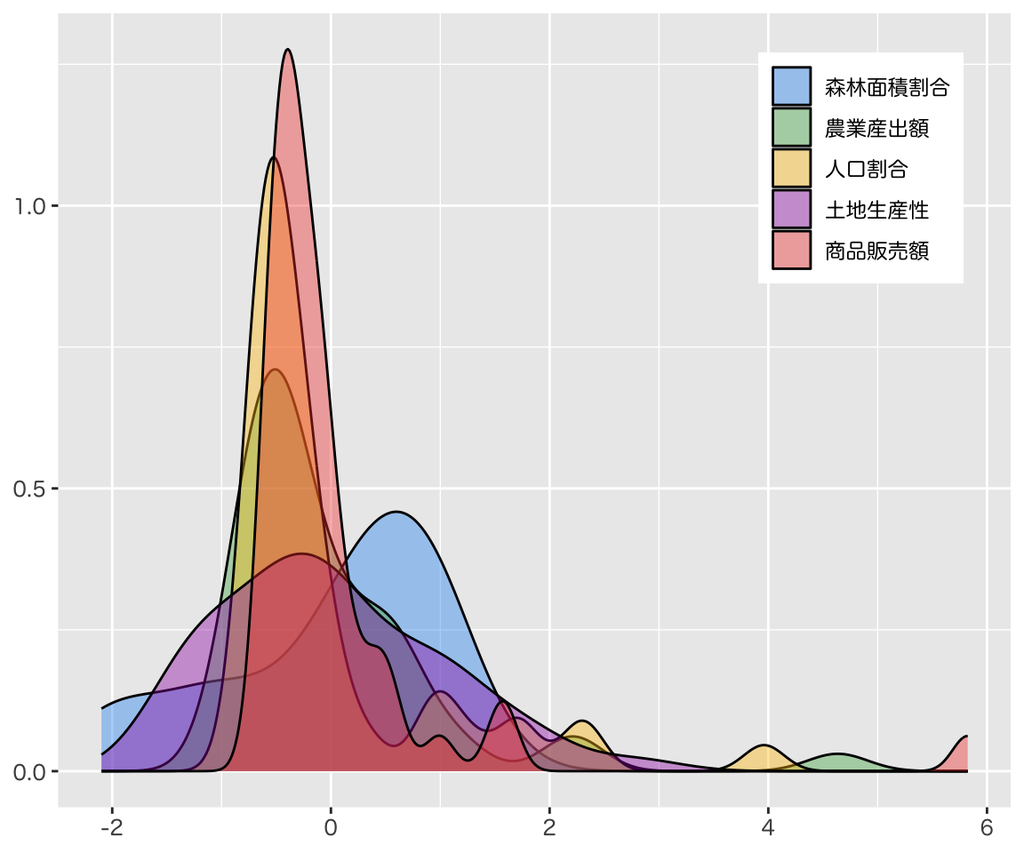

### 主成分負荷量を計算する (標準化後)

標準化した場合の主成分負荷量

| column | PC1 | PC2 | PC3 | PC4 | PC5 |
| --- | --- | --- | --- | --- | --- |
| 森林面積割合 | −0.4871 | 0.1046 | −0.4575 | 0.6860 | −0.2682 |
| 農業産出額 | 0.1339 | 0.8115 | 0.4791 | 0.3045 | 0.0348 |
| 人口割合 | 0.5851 | −0.1511 | 0.0447 | 0.1641 | −0.7784 |
| 土地生産性 | 0.3548 | 0.4851 | −0.7417 | −0.2897 | 0.0689 |
| 商品販売額 | 0.5258 | −0.2689 | −0.0952 | 0.5708 | 0.5624 |

- 主成分方向から読み取れること
  - 第1 : 人の多さに関する成分(正の向きほど人が多い)
  - 第2 : 農業生産力に関する成分(正の向きほど高い)

### 各主成分における負荷量の違いを確認する

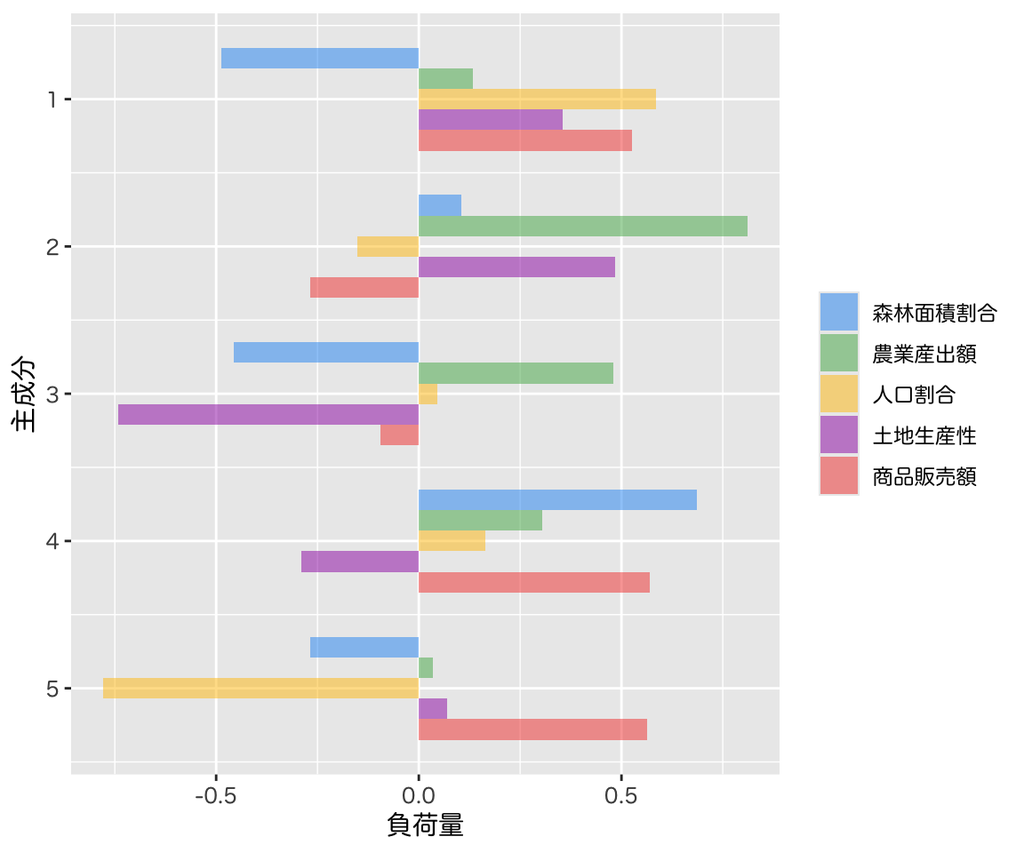

### 主成分得点を表示する

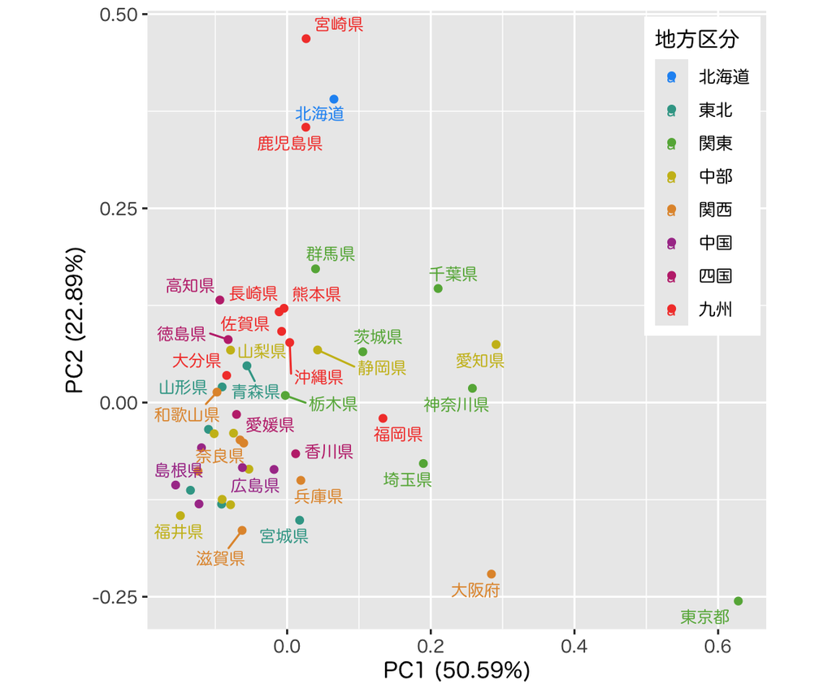

### データの標準化を行わない場合

標準化しない場合の主成分負荷量

| column | PC1 | PC2 | PC3 | PC4 | PC5 |
| --- | --- | --- | --- | --- | --- |
| 森林面積割合 | −0.0142 | 0.0482 | −0.0004 | −0.9975 | −0.0495 |
| 農業産出額 | 0.9729 | 0.1208 | −0.1971 | −0.0080 | 0.0004 |
| 人口割合 | 0.0022 | −0.0116 | 0.0000 | 0.0489 | −0.9987 |
| 土地生産性 | 0.2217 | −0.2467 | 0.9433 | −0.0155 | 0.0026 |
| 商品販売額 | 0.0647 | −0.9602 | −0.2672 | −0.0476 | 0.0090 |

- ばらつきの大きな変数に主成分方向が偏る

### 主成分負荷量を比較する

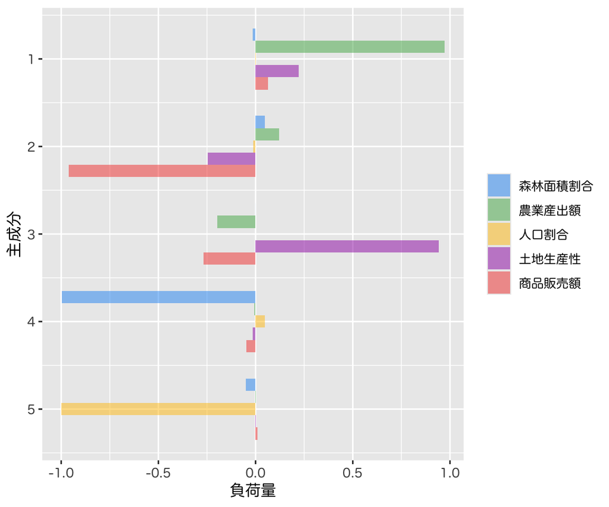

### 主成分得点を比較する

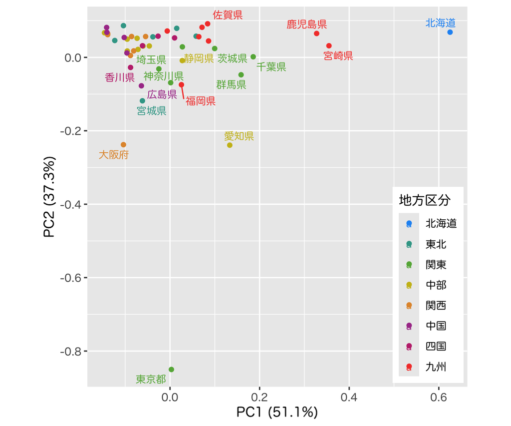

# 次回の予定

- 第1日 : 主成分分析の考え方
- **第2日 : 分析の評価と視覚化**